# Food Matching Framework

## Food Consumption Data

### 1. Identifying & obtaining the food consumption data

The apparent food consumption data from the National Panel Survey (NPS 2019-2020) Extended Panel with Sex Disaggregated Data (NPS-DSS 2019-2020) is extracted from the Module J1. This dataset has been previously indentified, obtained and explored in previous week. As summary, the Module J1 provides information on the food consumed by the household over the past one week.

For more information on this dataset, check the materials of Week 7 and 8.

### 2. Importing & Loading the food consumption data

Before running this chunck of code make sure that you have downloaded and stored the Module J1 of the NPS-DSS 2019-2020 in your `data` folder. In addition, check that in the `Week-10/data` folder you can see a dataset called `food-id.csv` which we are loading together with the Module J1. More information about `food-id.csv` is provided in the next section.

```r
# Loading the apparent food consumption data

dataJ1 <- read.csv(here::here("..", "tz_2020", "data", "HH_SEC_J1.csv"))

# Loading food ids

item_code <- read.csv(here::here("Week-10", "data", "food-id.csv"), header = TRUE)

# check the data
head(dataJ1)
```

```
  interview__key     sdd_hhid                   itemcode hh_j01 hh_j02_1
1    69-04-74-63 0001-001-001               RICE (PADDY)     NO
2    69-04-74-63 0001-001-001              RICE (HUSKED)     NO
3    69-04-74-63 0001-001-001         MAIZE (GREEN, COB)     NO
4    69-04-74-63 0001-001-001              MAIZE (GRAIN)     NO
5    69-04-74-63 0001-001-001              MAIZE (FLOUR)     NO
6    69-04-74-63 0001-001-001 MILLET AND SORGHUM (GRAIN)     NO
  hh_j02_2 hh_j03_1 hh_j03_2 hh_j04 hh_j05_1 hh_j05_2 hh_j06_1 hh_j06_2
1       NA                       NA
2       NA                       NA
3       NA                       NA
4       NA                       NA
5       NA                       NA
6       NA                       NA
```

```r
names(dataJ1)
```

```
 [1] "interview__key" "sdd_hhid"       "itemcode"       "hh_j01"
 [5] "hh_j02_1"       "hh_j02_2"       "hh_j03_1"       "hh_j03_2"
 [9] "hh_j04"         "hh_j05_1"       "hh_j05_2"       "hh_j06_1"
[13] "hh_j06_2"
```

```r
str(dataJ1)
```

```
'data.frame':   71040 obs. of  13 variables:
 $ interview__key: chr  "69-04-74-63" "69-04-74-63" "69-04-74-63" "69-04-74-63" ...
 $ sdd_hhid      : chr  "0001-001-001" "0001-001-001" "0001-001-001" "0001-001-001" ...
 $ itemcode      : chr  "RICE (PADDY)" "RICE (HUSKED)" "MAIZE (GREEN, COB)" "MAIZE (GRAIN)" ...
 $ hh_j01        : chr  "NO" "NO" "NO" "NO" ...
 $ hh_j02_1      : chr  "" "" "" "" ...
 $ hh_j02_2      : num  NA NA NA NA NA NA 7 NA NA NA ...
 $ hh_j03_1      : chr  "" "" "" "" ...
 $ hh_j03_2      : chr  "" "" "" "" ...
 $ hh_j04        : int  NA NA NA NA NA NA 4800 NA NA NA ...
 $ hh_j05_1      : chr  "" "" "" "" ...
 $ hh_j05_2      : chr  "" "" "" "" ...
 $ hh_j06_1      : chr  "" "" "" "" ...
 $ hh_j06_2      : chr  "" "" "" "" ...
```

```r
dim(dataJ1)
```

```
[1] 71040    13
```

```r
head(item_code)
```

```
  item_id                   itemcode
1     101               RICE (PADDY)
2     102              RICE (HUSKED)
3     103         MAIZE (GREEN, COB)
4     104              MAIZE (GRAIN)
5     105              MAIZE (FLOUR)
6     106 MILLET AND SORGHUM (GRAIN)
```

```r
names(item_code)
```

```
[1] "item_id"  "itemcode"
```

For this exercise, we are only interested in the food items that were consumed and the number of households that consumed each food item.

We are using the pipe to do all the operations needed in one code chuck (code block).

You should be familiar with each independent function as all of them have been used before. You can have more information about each individual tasks in the scripts used in Week-8 and Week-9.

```r
# Generating the food list of food consumed by the HH in Tanzania

(food_consumed <-  dataJ1 %>%
  rename(cons_yn = hh_j01) %>%  # renaming variable
  mutate(                                # changing variable class
    itemcode = as.factor(itemcode),
    cons_yn = as.factor(cons_yn)) %>%
  filter(cons_yn == "YES") %>%     # filtering food reported as consumed
  count(itemcode) %>%           # counting number of HH consuming a food
   arrange(desc(n))) # sorting foods by most HH reporting consuming that food
```

```
                                                   itemcode    n
1                                                      SALT 1089
2  ONIONS, TOMATOES, CARROTS AND GREEN PEPPER, OTHER VIUNGO 1045
3                                               COOKING OIL  978
4                                             MAIZE (FLOUR)  940
5                                                     SUGAR  877
6               SPINACH, CABBAGE AND OTHER GREEN VEGETABLES  875
7                     PEAS, BEANS, LENTILS AND OTHER PULSES  834
8                                             RICE (HUSKED)  748
9                                                   TEA DRY  667
10                 FRESH FISH AND SEAFOOD (INCLUDING DAGAA)  646
11       DRIED/SALTED/CANNED FISH AND SEAFOOD (INCL. DAGAA)  459
12                                 BUNS, CAKES AND BISCUITS  453
13                            BEEF INCLUDING MINCED SAUSAGE  420
14                                            CASSAVA FRESH  383
```

[output cut: 45 more lines]

As you can see, the Module J1 csv file doesn’t provide the food id. that was used in the NPS-DSS 2019-2020, we have created (and loaded) a dataset with each food name and its food code (`item_id`). We are merging the two datasets (`food_consumed` and `item_id`) together to obtain the food id. of each food consumed by the households. In addition, we are changing the order of the columns to improve readability of the dataset.

```r
# Adding the food id to the food consumed in Tanzania

(food_consumed <- food_consumed %>% left_join(., item_code) %>%  #Merging food ids. to the food consumed (food list)
  relocate(item_id, .before = itemcode)) # Changing the order of the columns
```

```
   item_id                                                 itemcode    n
1     1003                                                     SALT 1089
2      601 ONIONS, TOMATOES, CARROTS AND GREEN PEPPER, OTHER VIUNGO 1045
3     1001                                              COOKING OIL  978
4      105                                            MAIZE (FLOUR)  940
5      301                                                    SUGAR  877
6      602              SPINACH, CABBAGE AND OTHER GREEN VEGETABLES  875
7      401                    PEAS, BEANS, LENTILS AND OTHER PULSES  834
8      102                                            RICE (HUSKED)  748
9     1101                                                  TEA DRY  667
10     808                 FRESH FISH AND SEAFOOD (INCLUDING DAGAA)  646
11     809       DRIED/SALTED/CANNED FISH AND SEAFOOD (INCL. DAGAA)  459
12     110                                 BUNS, CAKES AND BISCUITS  453
13     802                            BEEF INCLUDING MINCED SAUSAGE  420
14     201                                            CASSAVA FRESH  383
```

[output cut: 45 more lines]

Finally, we have obtained a data.frame with the list of the foods consumed by the households, their food ids, and ordered by frequency of consumption (most to least). That dataset will be the base for the generating the Nutrient Conversion Table for nutrient intake assessment.

## Food Composition Data

### 1. Identifying & obtaining the food composition data

#### 1.1. Identifying the food composition data for use with the Tanzania NPS-DSS 2019-2020.

When identifying what food composition data will be used, we need to answer some of the following questions (which are related to the presentation of Week 9 - How to choose FCTs?).

1. Relevancy for the study/context (e.g., geographically and culturally close).
2. FCT availability & missing values (e.g., relevant foods and nutrients are reported)
3. Data quality and reporting (e.g., method of analysis, good metadata)

##### 1.1.1. Relevancy for the study/context (e.g., geographically and culturally close).

**Question 1**

What FCTs do you know from the region? And, what FCT would you use for this study?

**Answer 1**

There are more than 19FCTs in the region, we have selected and are reported in the protocol the following:

**Tanzania FCT, 2008** > Western Africa FCT, 2019 > Kenya FCT, 2018 > USDA FCT, 2019 > UK FCT, 2020. Other specific FCTs like uFish and/or uPulses may be used as well.

After selecting the most relevant FCT(s), we need to check whether it contains the information we need for the objective of our study.

##### 1.1.2. FCT availability & missing values (e.g., relevant foods and nutrients are reported)

Here, we need to check if the FCT(s) that we have selected contains the foods reported consumed in the household survey and the nutrients that we will be evaluating in our study.

**Question 2**

How many foods are reported in the Tanzania FCT?

**Answer 2**

378

**Question 3**

What nutrients and other food components are reported?

**Answer 3**

We need to report certain nutrients, do you know which ones? (Vitamin A, thiamine, riboflavin, niacin, folate, vitamin B6, vitamin B12, iron, and zinc)

**Question 4**

What nutrients and other important food components are missing?

**Answer 4**

Information of edible portion and water (moisture) content is missing.

Once, we have checked that most of the foods and nutrients that we need are reported in the FCT(s) selected, we need to check the quality of the data provided, as it would condition the results of our analysis.

##### 1.1.3. Data quality and reporting (e.g., method of analysis, good metadata)

General quality checks are: the level of detail in the food description, the methods used for nutrient values compilation, and the documentation and degree of detail.

Other quality checks that can be performed are: calculating sum of proximate and re-calculating the values of: Carbohydrates available by difference, energy, etc.

**Question 5**

Why are those components important for the food matching process?

**Answer 5**

Water content is essential to differentiate foods, and to identify if food are dry/fresh. In addition, for calculating SOP, re-calculating some food components, and it is vital for imputing values when necessary. ]

Edible portion is necessary to calculate the part of the foods that people are consuming, and this is usually context specific. Hence, it should be reported in the national FCT.

#### 1.2. Obtaining the food composition data for use with the Tanzania NPS-DSS 2019-2020.

[Tanzania FCT, 2008](http://www.hsph.harvard.edu/nutritionsource/food-tables/)  
[Western Africa, 2019](https://www.fao.org/fileadmin/user_upload/faoweb/2020/WAFCT_2019.xlsx)  
[Kenya FCT, 2018](https://www.fao.org/3/I8897EN/i8897en.pdf)  
[USDA, 2019](https://fdc.nal.usda.gov/)  
[COFID, 2021](https://assets.publishing.service.gov.uk/government/uploads/system/uploads/attachment_data/file/971018/McCance_Widdowsons_Composition_of_Foods_Integrated_Dataset_2021..xlsx)  
[uFish, 2016](https://www.fao.org/fileadmin/templates/food_composition/documents/uFiSh1.0.xlsx)  
[uPulses, 2017](https://www.fao.org/fileadmin/templates/food_composition/documents/uPulses1.0.xlsx)

### 2. Importing & Loading Food Composition Tables

Before running this scripts make sure that the file `TZ08_tidied_FCT_v2.CSV` is loaded in your `data\` folder.

#### 2.1 Loading the Tanzania FCT, 2008

For the following data check we will focus on the Food Composition Data from the Tanzania FCT, 2008.

```r
# Loading the food composition data

tzfct <- read.csv(here::here("..",  "data", "TZ08_tidied_FCT_v2.CSV"))

# check the data
head(tzfct)
```

```
  fdc_id food_description Food_Group_Code                 Food_Group source_fct
1      1          Biscuit              A1 Cereal and Cereal products       TZ08
2      2       Bread roll              A1 Cereal and Cereal products       TZ08
3      3     Bread, white              A1 Cereal and Cereal products       TZ08
4      6             Cake              A1 Cereal and Cereal products       TZ08
5      7           Cookie              A1 Cereal and Cereal products       TZ08
6      8            Donut              A1 Cereal and Cereal products       TZ08
  nutrient_data_source ENERCkcal PROCNTg PROANIg MFP_PROTg FAT_g FASATg FAMSg
1          None listed       434     9.2     0.0         0  11.8    2.1   6.5
2          None listed       274     8.8     0.0         0     3    0.6   1.2
3          None listed       274     8.8     0.0         0     3    0.6   1.2
4          None listed       320     4.7     2.2         0  12.3    3.5   5.3
5          None listed       478     5.1     0.0         0  21.1    5.4  11.8
6          None listed       478     5.1     0.0         0  21.1    5.4  11.8
  FAPUg            CHOCDFg CHOLEmg FIB_g SUCSg PHYTACmg VITA_RAEmcg A_VITAmcg
```

[output cut: 27 more lines]

```r
names(tzfct)
```

```
 [1] "fdc_id"               "food_description"     "Food_Group_Code"
 [4] "Food_Group"           "source_fct"           "nutrient_data_source"
 [7] "ENERCkcal"            "PROCNTg"              "PROANIg"
[10] "MFP_PROTg"            "FAT_g"                "FASATg"
[13] "FAMSg"                "FAPUg"                "CHOCDFg"
[16] "CHOLEmg"              "FIB_g"                "SUCSg"
[19] "PHYTACmg"             "VITA_RAEmcg"          "A_VITAmcg"
[22] "VITDmcg"              "VITEmcg"              "VITCmg"
[25] "THIAmg"               "RIBFmg"               "NIAmg"
[28] "VITB6_mg"             "FOLmcg"               "VITB12mg"
[31] "PANTACmg"             "TRPmg"                "THRmg"
[34] "ILEmg"                "LEUmg"                "LYSmg"
[37] "METmg"                "CYSmg"                "PHEmg"
[40] "TYRmg"                "VALmg"                "ARGmg"
[43] "HISmg"                "CAmg"                 "Pmg"
[46] "MGmg"                 "Kmg"                  "NAmg"
[49] "FEmg"                 "MFP_FEmg"             "ZNmg"
[52] "CUmg"                 "MNmg"
```

```r
str(tzfct)
```

```
'data.frame':   378 obs. of  53 variables:
 $ fdc_id              : int  1 2 3 6 7 8 9 33 10 11 ...
 $ food_description    : chr  "Biscuit" "Bread roll" "Bread, white" "Cake" ...
 $ Food_Group_Code     : chr  "A1" "A1" "A1" "A1" ...
 $ Food_Group          : chr  "Cereal and Cereal products" "Cereal and Cereal products" "Cereal and Cereal products" "Cereal and Cereal products" ...
 $ source_fct          : chr  "TZ08" "TZ08" "TZ08" "TZ08" ...
 $ nutrient_data_source: chr  "None listed" "None listed" "None listed" "None listed" ...
 $ ENERCkcal           : num  434 274 274 320 478 478 387 371 119 362 ...
 $ PROCNTg             : num  9.2 8.8 8.8 4.7 5.1 5.1 14 10.5 2.7 8.1 ...
 $ PROANIg             : num  0 0 0 2.2 0 0 8.5 0 0 0 ...
 $ MFP_PROTg           : num  0 0 0 0 0 0 0 0 0 0 ...
 $ FAT_g               : chr  "11.8" "3" "3" "12.3" ...
 $ FASATg              : num  2.1 0.6 0.6 3.5 5.4 5.4 0.5 0.2 0.2 0.5 ...
 $ FAMSg               : num  6.5 1.2 1.2 5.3 11.8 11.8 0.2 0.1 0.3 0.9 ...
 $ FAPUg               : num  1.8 0.7 0.7 2.9 2.7 2.7 0.2 0.4 0.5 1.6 ...
```

[output cut: 39 more lines]

```r
dim(tzfct)
```

```
[1] 378  53
```

```r
View(tzfct)
```

### 3. Standardisation of the Food Composition Tables

Note that this FCT has already been cleaned and prepared for the food matching (see Week 9). Hence, we would be skipping the step 2 of the framework: “Data Standardisation”. Some of the most common standardisation operations for FCTs were covered in Week9. If anyone is interested in knowing more about that, we could share more information about how the Tanzania FCT, 2008 and other FCTs are cleaned and standardised.

#### 3.1. Evaluating the Tanzania FCT, 2008

1. How many foods are reported in the Tanzania FCT?

```r
length(tzfct$food_description)
```

```
[1] 378
```

We can also check the number of foods reported in each Food Group?

```r
tzfct %>% group_by(Food_Group) %>%  # grouping food items by food groups
  count() %>%               # counting no. of food items per food group
  arrange(desc(n))         # sorting by most to least reported foods
```

```
# A tibble: 16 × 2
# Groups:   Food_Group [16]
   Food_Group                                      n
   <chr>                                       <int>
 1 Cereal-based local dishes                      36
 2 Fruits and Fruit Juice                         35
 3 Vegetables                                     34
 4 Cereal and Cereal products                     31
 5 Miscellaneous                                  31
 6 Vegetables Based                               31
 7 Roots, Tubers and Banana-based local dishes    29
 8 Meat, poultry and fish-based local dishes      28
 9 Pulses, Nuts and Seeds                         27
10 Meat, poultry and fish                         23
11 Roots, Tubers and Banana                       17
12 Pulses, Nuts and Seeds-based local dishes      15
13 Oils and fats                                  14
14 Milk and milk products                         11
15 Fruit Based Local Dishes                        8
16 Miscellaneous-local dishes                      8
```

2. What nutrients and other food components are reported?

```r
names(tzfct)
```

```
 [1] "fdc_id"               "food_description"     "Food_Group_Code"
 [4] "Food_Group"           "source_fct"           "nutrient_data_source"
 [7] "ENERCkcal"            "PROCNTg"              "PROANIg"
[10] "MFP_PROTg"            "FAT_g"                "FASATg"
[13] "FAMSg"                "FAPUg"                "CHOCDFg"
[16] "CHOLEmg"              "FIB_g"                "SUCSg"
[19] "PHYTACmg"             "VITA_RAEmcg"          "A_VITAmcg"
[22] "VITDmcg"              "VITEmcg"              "VITCmg"
[25] "THIAmg"               "RIBFmg"               "NIAmg"
[28] "VITB6_mg"             "FOLmcg"               "VITB12mg"
[31] "PANTACmg"             "TRPmg"                "THRmg"
[34] "ILEmg"                "LEUmg"                "LYSmg"
[37] "METmg"                "CYSmg"                "PHEmg"
[40] "TYRmg"                "VALmg"                "ARGmg"
[43] "HISmg"                "CAmg"                 "Pmg"
[46] "MGmg"                 "Kmg"                  "NAmg"
[49] "FEmg"                 "MFP_FEmg"             "ZNmg"
[52] "CUmg"                 "MNmg"
```

#### 3.2 Checking missing values

##### 3.2.1. Checking food components

We can see that for those food items reported in the Tanzania FCT, 2008. There were no missing values for any of the nutrients. This would prevent us from needing to impute nutrient values for any of the food matched to the Tanzania FCT, 2008 foods.

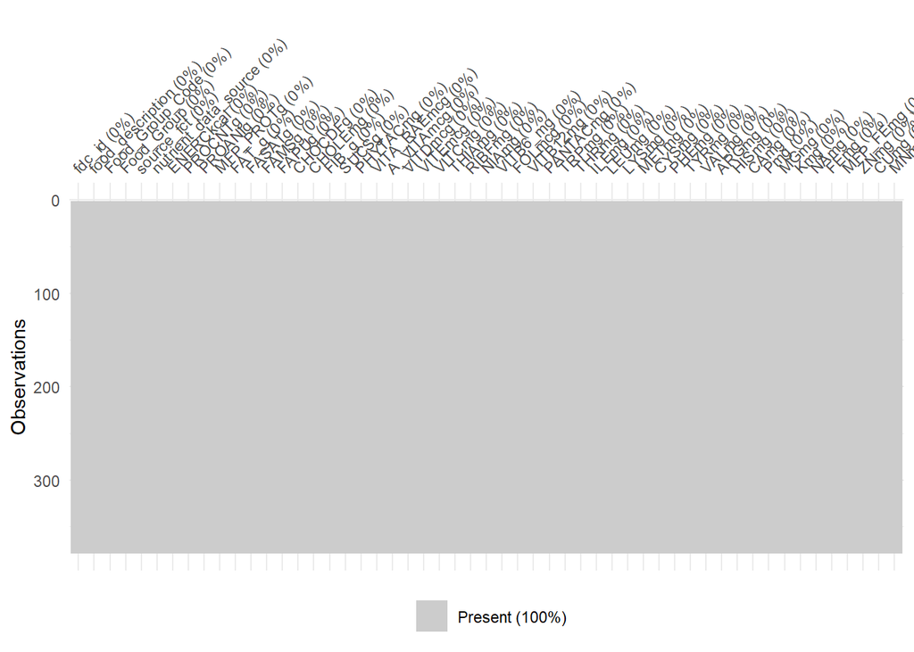

```r
tzfct %>% naniar::vis_miss()
```

**Question 6**

What components are needed to calculate Energy?

**Answer 6**

Proteins, Total fats, Carbohydrates (available), Fibre and Alcohol.

We can see that in the Tanzania FCT, 2008, Alcohol is not reported, this is problematic when we want to calculate and/or compare alcoholic beverages such as beer.

```r
# what components are needed to calculate Energy?

tzfct %>%
  select(fdc_id, food_description, PROCNTg, FAT_g, CHOCDFg, FIB_g) %>% head()
```

```
  fdc_id food_description PROCNTg FAT_g            CHOCDFg FIB_g
1      1          Biscuit     9.2  11.8               71.5   2.7
2      2       Bread roll     8.8     3               51.9   2.8
3      3     Bread, white     8.8     3               51.9   2.8
4      6             Cake     4.7  12.3               48.6   0.6
5      7           Cookie     5.1  21.1 67.900000000000006   0.5
6      8            Donut     5.1  21.1 67.900000000000006   0.5
```

**Question 7**

What components are needed to calculate Sum of Proximate (SOP)?

**Answer 7**

Water, Proteins, Total fats, Carbohydrates (available), Fibre and Alcohol.

We can see that alcohol, and more importantly water content is not available in the Tanzania FCT, 2008. Therefore, we will not be able to calculate this component which is often used to evaluate the quality of the data.

```r
# what components are needed to calculate SOP?

tzfct %>%
  select(fdc_id, food_description,  PROCNTg, FAT_g, CHOCDFg, FIB_g) %>% head()
```

```
  fdc_id food_description PROCNTg FAT_g            CHOCDFg FIB_g
1      1          Biscuit     9.2  11.8               71.5   2.7
2      2       Bread roll     8.8     3               51.9   2.8
3      3     Bread, white     8.8     3               51.9   2.8
4      6             Cake     4.7  12.3               48.6   0.6
5      7           Cookie     5.1  21.1 67.900000000000006   0.5
6      8            Donut     5.1  21.1 67.900000000000006   0.5
```

##### 3.2.2. Checking food reported

It is important to check the coverage of foods and food groups.

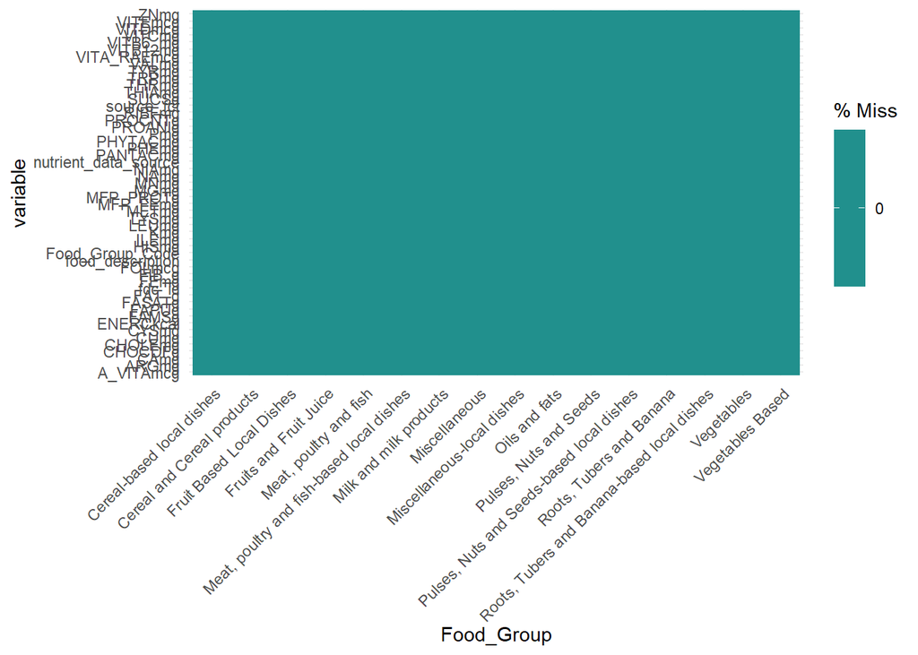

```r
tzfct %>% naniar::gg_miss_fct(., Food_Group)
```

Here, we are filtering the foods in the FCT by a specific food group, for instance “Cereals and Cereals products”.

There are other food groups in the Tanzania FCT, 2008:

Cereal and Cereal products, Cereal-based local dishes, Roots, Tubers and Banana, Roots, Tubers and Banana-based local dishes, Pulses, Nuts and Seeds, Pulses, Nuts and Seeds-based local dishes, Meat, poultry and fish, Meat, poultry and fish-based local dishes, Milk and milk products, Oils and fats, Fruits and Fruit Juice, Fruit Based Local Dishes, Vegetables, Vegetables Based, Miscellaneous, Miscellaneous-local dishes

```r
# Exploring composition of the foods groups

tzfct %>% filter(Food_Group == "Cereal and Cereal products") %>%
  select(fdc_id, food_description, ENERCkcal, VITA_RAEmcg)
```

```
   fdc_id                     food_description ENERCkcal VITA_RAEmcg
1       1                              Biscuit     434.0         0.0
2       2                           Bread roll     274.0         0.0
3       3                         Bread, white     274.0         0.0
4       6                                 Cake     320.0        34.0
5       7                               Cookie     478.0        27.0
6       8                                Donut     478.0        27.0
7       9               Infant cereal, Cerelac     387.0         3.0
8      33                Macaroni or spaghetti     371.0         0.0
9      10               Maize, cracked, cooked     119.0         0.0
10     11                    Maize, dried, raw     362.0         0.0
11     12                    Maize, flour, dry     362.0         0.0
12     13                 Maize, green, cooked     246.0         0.0
13     14          Maize, on the cob, immature      59.0         7.0
14     15                 Maize, yellow, flour     362.0        11.0
```

[output cut: 17 more lines]

More importantly, we need to check that the foods reported as consumed by the household members are present in the FCT(s) that we are using.

Let’s have a look at the food list…

```r
knitr::kable(food_consumed)
```

| item_id | itemcode | n |
| --- | --- | --- |
| 1003 | SALT | 1089 |
| 601 | ONIONS, TOMATOES, CARROTS AND GREEN PEPPER, OTHER VIUNGO | 1045 |
| 1001 | COOKING OIL | 978 |
| 105 | MAIZE (FLOUR) | 940 |
| 301 | SUGAR | 877 |
| 602 | SPINACH, CABBAGE AND OTHER GREEN VEGETABLES | 875 |
| 401 | PEAS, BEANS, LENTILS AND OTHER PULSES | 834 |
| 102 | RICE (HUSKED) | 748 |
| 1101 | TEA DRY | 667 |
| 808 | FRESH FISH AND SEAFOOD (INCLUDING DAGAA) | 646 |
| 809 | DRIED/SALTED/CANNED FISH AND SEAFOOD (INCL. DAGAA) | 459 |
| 110 | BUNS, CAKES AND BISCUITS | 453 |
| 802 | BEEF INCLUDING MINCED SAUSAGE | 420 |
| 201 | CASSAVA FRESH | 383 |
| 702 | CITRUS FRUITS (ORANGES, LEMON, TANGERINES, ETC.) | 375 |
| 502 | COCONUTS (MATURE/IMMATURE) | 374 |
| 206 | COOKING BANANAS, PLANTAINS | 368 |
| 703 | MANGOES, AVOCADOES AND OTHER FRUITS | 349 |
| 205 | IRISH POTATOES | 344 |
| 203 | SWEET POTATOES | 335 |
| 701 | RIPE BANANAS | 293 |
| 901 | FRESH MILK | 262 |
| 109 | BREAD | 228 |
| 1081 | WHEAT FLOUR | 216 |
| 501 | GROUNDNUTS IN SHELL/SHELLED | 214 |
| 1104 | BOTTLED/CANNED SOFT DRINKS (SODA, JUICE, WATER) | 211 |
| 807 | EGGS | 207 |
| 804 | CHICKEN AND OTHER POULTRY | 206 |
| 202 | CASSAVA DRY/FLOUR | 186 |
| 1004 | OTHER SPICES | 153 |
| 704 | SUGARCANE | 140 |
| 902 | MILK PRODUCTS (LIKE CREAM, CHEESE, YOGHURT ETC) | 110 |
| 111 | MACARONI, SPAGHETTI | 106 |
| 103 | MAIZE (GREEN, COB) | 103 |
| 204 | YAMS/COCOYAMS | 99 |
| 104 | MAIZE (GRAIN) | 97 |
| 107 | MILLET AND SORGHUM (FLOUR) | 89 |
| 303 | HONEY, SYRUPS, JAMS, MARMALADE, JELLIES, CANNED FRUITS | 88 |
| 801 | GOAT MEAT | 86 |
| 603 | CANNED, DRIED AND WILD VEGETABLES | 84 |
| 302 | SWEETS | 62 |
| 803 | PORK INCLUDING SAUSAGES AND BACON | 49 |
| 1002 | BUTTER, MARGARINE, GHEE AND OTHER FAT PRODUCTS | 41 |
| 1107 | LOCAL BREWS | 39 |
| 1103 | OTHER RAW MATERIALS FOR DRINKS | 35 |
| 1106 | BOTTLED BEER | 23 |
| 112 | OTHER CEREAL PRODUCTS | 15 |
| 503 | CASHEW, ALMONDS AND OTHER NUTS | 12 |
| 1102 | COFFEE AND COCOA | 11 |
| 903 | CANNED MILK/MILK POWDER | 10 |
| 207 | OTHER STARCHES | 6 |
| 101 | RICE (PADDY) | 5 |
| 1082 | WHEAT, BARLEY GRAIN AND OTHER CEREALS | 5 |
| 1108 | WINE AND SPIRITS | 5 |
| 106 | MILLET AND SORGHUM (GRAIN) | 4 |
| 504 | SEEDS AND PRODUCTS FROM NUTS/SEEDS (EXCL. COOKING OIL) | 2 |
| 806 | OTHER DOMESTIC/WILD MEAT PRODUCTS | 1 |
| 1105 | PREPARED TEA, COFFEE | 1 |
| 805 | WILD BIRDS AND INSECTS | 1 |

Let’s find some of those food items: salt, tomato

```r
tzfct %>% filter(grepl("salt|tomato", food_description, ignore.case = TRUE))
```

```
   fdc_id                              food_description Food_Group_Code
1     537         Vermicelli with coconut milk and salt              A2
2     354                 Potato, crisps, plain, salted              B1
3     970                    Taro, cooked, without salt              B2
4     153    Beans, kidney, mature, boiled without salt              C1
5     176 Hyacinth-beans, immature, boiled without salt              C1
6     557        Small dried fish with tomatoes and oil              D2
7    1101                              Butter with salt               E
8     405              Cauliflower, cooked without salt              F3
9     421            Tomato, bitter (African egg plant)              F3
10    422                                 Tomato, green              F3
11    423                                  Tomato, ripe              F3
12    785                                 Tomato relish              F4
13    463                                 Salt, iodized              G1
14    464                             Salt, non-iodized              G1
```

[output cut: 129 more lines]

**Question 8**

The foods above, to what food groups do they belong?

**Answer 8**

Cereal-based local dishes, Roots, Tubers and Banana, Roots, Tubers and Banana-based local dishes, Pulses, Nuts and Seeds, Meat, poultry and fish-based local dishes, Oils and fats, Vegetables, Vegetables Based, Miscellaneous

Now, we can explore composition of filtered foods. Let’s see the Vitamin A content of the different tomato products.

```r
tzfct %>% filter(grepl("tomato", food_description, ignore.case = TRUE)) %>%
  select(fdc_id, food_description,  VITA_RAEmcg )
```

```
  fdc_id                       food_description VITA_RAEmcg
1    557 Small dried fish with tomatoes and oil        34.4
2    421     Tomato, bitter (African egg plant)        13.0
3    422                          Tomato, green        87.0
4    423                           Tomato, ripe        87.0
5    785                          Tomato relish        56.0
6    489                           Tomato juice        80.0
7    470                         Tomato ketchup       100.0
8    478                           Tomato paste       261.0
```

**Activity 1: What do you think about the results? How do they compare with other FCTs?**

1. What do you think about the Vitamin A content of green tomato vs red tomato?

### 4. Harmonising the Food Composition Tables

When all the FCTs are standardised, we can use them all together, hence if a food item is missing in Tanzania FCT, 2008, then a similar food item will be found in another FCT.

#### 4.1. Food matching

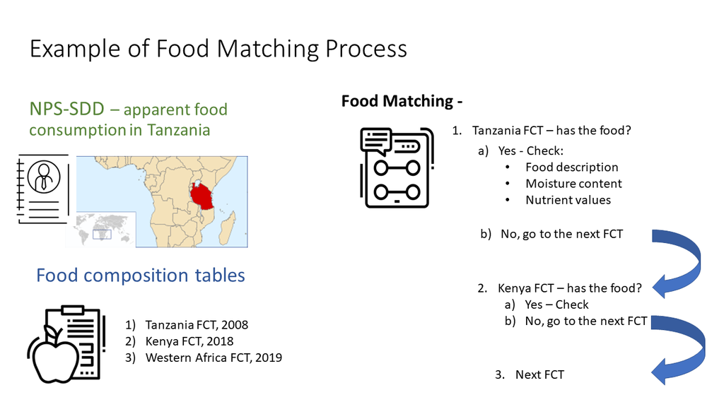

**Activity 2: Thinking about food matches between HCES food list and food composition.**

```r
matches <- read.csv(here::here("Week-10",  "data", "tz_food-matches_v.1.0.0.csv"))
```

[Tanzania matches](https://github.com/dzvoti/TFNC-Training/blob/main/Week-10/Materials/data/tz_food-matches_v.1.0.0.csv)

1. Do you think that the food matches selected represents well what it is consumed in Tanzania?
2. If not, what other foods would you add/remove/change to?
3. For the foods without matches, can you think of what food items you would use?
4. Could you identify any food matches in the Tanzania FCT, 2008 that will be a good match for those foods that have no matches?
5. What nutrients are important for each of the foods selected?

## Further Readings

- Greenfield, Heather, and D. A. T. Southgate. Food Composition Data: Production, Management, and Use. Rome: FAO, 2003.
- ‘FAO/INFOODS (2012). FAO/INFOODS Guidelines for Checking Food Composition Data Prior to the Publication of a User Table/Database-Version 1.0. FAO, Rome’. Accessed 22 January 2022. https://www.fao.org/3/ap810e/ap810e.pdf.